# final

yo

3 de mayo de 2017

Variables

id2 ID $ TP_VIVIENDA_SEPO tipo de vivienda $ TP_SUBSEGMENTO clasificación del cliente $ TP_SEGMENTO_FINAL2 Segmento de ciclo de vida $ TP_PERSONA Persona Física o moral $ TP_NIVEL_IR_AJUSTADO nivel de ingresos anuales estimados $ TP_DOMICILIO Tipo de domicilio $ TO_RANGO_EDAD Rango de edad del cliente $ TO_PROM_TO_OPERS_TARJ_TDC_3M número de transacciones promedio mensuales hechas con TDC en los últimos 3 meses $ TO_PROM_TO_CARGOS_6M promedio del numero de cargos en los últimos 6 meses $ TO_PROM_TO_CARGOS_3M promedio del numero de cargos en los últimos 3 meses $ TO_PREST_CONSUMO número de préstamos contratados en el último año $ TO_PLAZO cuenta con algún producto de inversión $ TO_NECESIDAD_FINAN_CAP_3M Ratio de captación vs. Créditos en los últimos 3 meses $ TO_NECESIDAD_FINAN_CAP_1M Ratio de captación vs. Créditos en el último mes $ TO_MISS_TO_SDO_MEDIO_2MA saldo medio fue reportado hace 2 meses $ TO_MISS_TO_SDO_MEDIO_1M se ha reportado el saldo medio en el último mes $ TO_MISS_TO_SDO_CORTE_2MA saldo al corte fue reportado hace 2 meses $ TO_MISS_SDO_MEDIO_3M número de veces que no se ha reportado el saldo medio en los últimos 3 meses $ TO_MISS_SDO_CORTE_3M número de veces que no se ha reportado el saldo al corte en los últimos 3 meses $ TO_MISS_SDO_CORTE_1M se ha reportado el saldo al corte n el último mes $ TO_MISS_FONDOS_AES_3M se ha reportado el saldo de fondos AES en los últimos 3 meses $ TO_MISS_ACTIVO_TOTAL_3M número de veces que el cte ha estado activo en los últimos 3 meses $ TO_MERCADOS número de productos de mercado de capitales/divisas/dinero $ TO_IR_AJUSTADO estimación de ingresos anuales $ TO_FONDOS_AES número de fondos /avanzados/esenciales y selectos $ TO_FONDO_RV tiene fondos de renta variable $ TO_FONDO_RF tiene fondos de renta fja $ TO_DELTA_TO_PREST_CONSUMO_0_2 delta del número de créditos al consumo en los último 3 meses $ TO_DELTA_NEC_FIN_CAP_0_2 delta de necesidad financiera con respecto a 3 meses anteriores $ TO_CTA_HIPOTECA tiene algún crédito hipotecario vigente $ NU_VINC_COGNODATA Estimación de la fidelidad del cliente $ NU_VINC_BANCOMER índice de fidelidad $ NU_REGULARIDAD_TDC_ULT_6M Frecuencia mensual de uso de la tdc en los últimos 6 ,meses $ IM_SUM_SDO_MEDIO_3M suma de saldos medios captación mensuales de los últimos 3 meses $ IM_SUM_SDO_MEDIO_1M suma de saldos medios captación mensuales de los último mes $ IM_SUM_SDO_CORTE_3M suma de saldos a la fecha de corte de los últimos 3 meses $ IM_SUM_SDO_CORTE_1M suma de saldos a la fecha de corte del último mes $ IM_SUM_IM_SDO_MEDIO_2MA saldo medio 2 meses antes $ IM_SUM_IM_SDO_CORTE_2MA saldo al corte 2 meses antes $ IM_SUM_FONDOS_AES_3M suma de saldo promedio de fondos AES en los últimos 3 meses $ IM_SUM_ACTIVO_TOTAL_3M suma de saldos de todos los créditos en los últimos 3 meses $ IM_PROM_VISTA_6M saldo promedio de captacion de los últimos 6 meses $ IM_PROM_VISTA_3M saldo promedio de captacion de los últimos 3 meses $ IM_PROM_VISTA_12M saldo promedio de captacion de los últimos 12 meses $ IM_PROM_SDO_MEDIO_3M promedio mensual de saldos en los últimos 3 meses $ IM_PROM_SDO_MEDIO_1M promedio mensual de saldos en el último mes $ IM_PROM_SDO_MEDIO_12M promedio mensual de saldos en los últimos 12 meses $ IM_PROM_SDO_CORTE_3M promedio mensual de saldos al corte de los últimos 3 meses $ IM_PROM_SDO_CORTE_1M promedio mensual de saldos al corte del último mes $ IM_PROM_SDO_CORTE_12M promedio mensual de saldos al corte de los últimos 12 meses $ IM_PROM_PREST_NOM_12M importe promedio mensual de préstamos de nómina en los últimos 12 meses $ IM_PROM_PREST_CONSUMO_6M importe promedio mensual de préstamos al consumo en los últimos 6 meses $ IM_PROM_PREST_CONSUMO_3M importe promedio mensual de préstamos al consumo en los últimos 3 meses $ IM_PROM_PREST_CONSUMO_1M importe promedio mensual de préstamos al consumo en el último mes $ IM_PROM_PPIS_12M importe promedio mensual de ppis en los últimos 12 meses $ IM_PROM_PLAZO_12M importe promedio mensual en plazos en los últimos 12 meses $ IM_PROM_OTRO_12M importe promedio mensual de otros productos en los últimos 12 meses $ IM_PROM_NOMINA_3M importe promedio de depósitos e nómina en los últimos 3 meses $ IM_PROM_MERCADOS_12M importe promedio de sados en productos de mercados cap, div, in $ IM_PROM_IM_OPERS_TARJ_TDC_6M importe promedio mensual de pagos con tdc en los últimos 6 meses $ IM_PROM_IM_OPERS_TARJ_TDC_3M importe promedio mensual de pagos con tdc en los últimos 3 meses $ IM_PROM_IM_OPERS_TARJ_TDC_1M importe promedio mensual de pagos con tdc en el último mes $ IM_PROM_IM_NIBT_TOTAL_12M rentabilidad promedio mensual del cte. en el útimo año $ IM_PROM_IM_CARGOS_6M importe promedio de cargos de los últimos 6 meses $ IM_PROM_IM_CARGOS_3M importe promedio de cargos de los últimos 3 meses $ IM_PROM_IM_CARGOS_1M importe promedio de cargos de los último mes $ IM_PROM_IM_CARGOS_12M importe promedio de cargos de los últimos 12 meses $ IM_PROM_HIPOTECA_12M importe promedio de pagos de hipoteca en los últimos 12 meses $ IM_PROM_GASTOS_3M importe promedio de gastos en los últimos 3 meses $ IM_PROM_GASTOS_1M importe promedio de gastos en el último mes $ IM_PROM_FONDOS_AES_12M importe promedio de saldos de fondos avanzaos/esenciales y selectos $ IM_PROM_FONDO_RV_12M importe promedio del saldo en fondos de renta variable de los últimos 12 meses $ IM_PROM_FONDO_RF_12M importe promedio del saldo en fondos de renta fija de los últimos 12 meses $ IM_PROM_CUOTA_TOT_ULT_3M importe promedio de cuota de tdc pagada en los últimos 3 meses $ IM_PROM_CUOTA_TOT_ULT_1M importe promedio de cuota de tdc pagada en los último mes $ IM_PROM_CARTERA_12M promedio del saldo de créditos de los últimos 12 meses $ IM_PROM_AUTO_12M importe promedio de pagos de crédito auto en los últimos 12 meses $ IM_PROM_ACTIVO_1M importe promedio mensual de pagos a créditos en el último mes $ IM_PROM_ACTIVO_12M importe promedio mensual de pagos a créditos en los últimos 12 meses $ IM_MAX_SDO_MEDIO_12M saldo máximo en los último 12 meses $ IM_DELTA_IM_SDO_MEDIO_0_2 delta de saldo medio actual vs. Hace 2 meses $ IM_DELTA_IM_SDO_CORTE_0_2 delta de saldo al corte actual vs. Hace 2 meses $ IM_COC_IM_SDO_CORTE_ACTIVO_0_2  
$ IM_COC_IM_FONDOS_AES_CAP_0_2  
$ contrata variable de respuesta: 1 contrata y 0. e.o.c $ CD_SEXO sexo $ CD_SEGMENTACION segmento operativo $ CD_RESIDENCIA País de Residencia $ CD_OCUPACION Ocupación $ CD_ESTADO Estado del Cliente $ CD_EDO_CIVIL estado civil -

******rangos******** edad: if edad, <= 37 then rango_edad = 0; else if coalesce(edad,0) > 37 and coalesce(edad,0) <= 44 then rango_edad = 1; else if coalesce(edad,0) > 44 and coalesce(edad,0) <= 52 then rango_edad = 2; else if coalesce(edad,0) > 52 and coalesce(edad,0) <= 62 then rango_edad = 3; else rango_edad = 4;

case when 0 < ingreso_anual <= 50000.0 then ‘1_RENTA BAJA’ when ingreso_anual > 50000.0 and ingreso_anual <= 120000.0 then ‘2_RENTA MEDIA BAJA’ when ingreso_anual > 120000.0 and ingreso_anual <= 250000.0 then ‘3_RENTA MEDIA ALTA’ when ingreso_anual > 250000.0 and ingreso_anual < 450000.0 then ‘4_RENTA ALTA’ when ingreso_anual >= 450000.0 then ‘5_RENTA MUY ALTA’

[figure not shown]

```r
multiv<-read.csv('/home/abraham/multivsamp.csv',sep=';')
library(Amelia)
missmap(multiv, main="Missings",
        col=c("yellow", "black"), legend=FALSE)
```

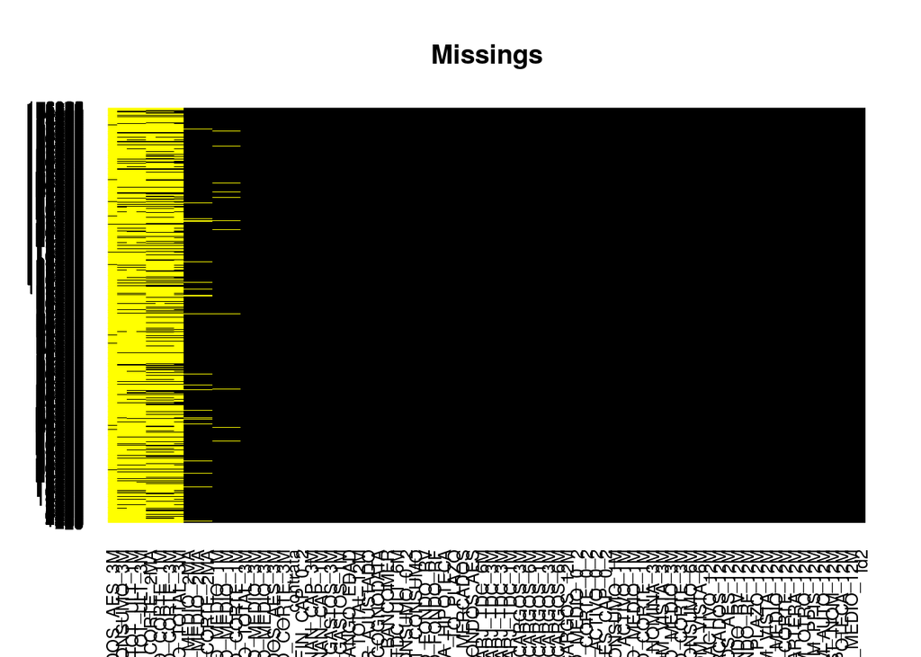

```r
cmult<-multiv[sapply(multiv, function(x) is.numeric(x))]
missmap(cmult, main="Missings",
        col=c("yellow", "black"), legend=FALSE)
```

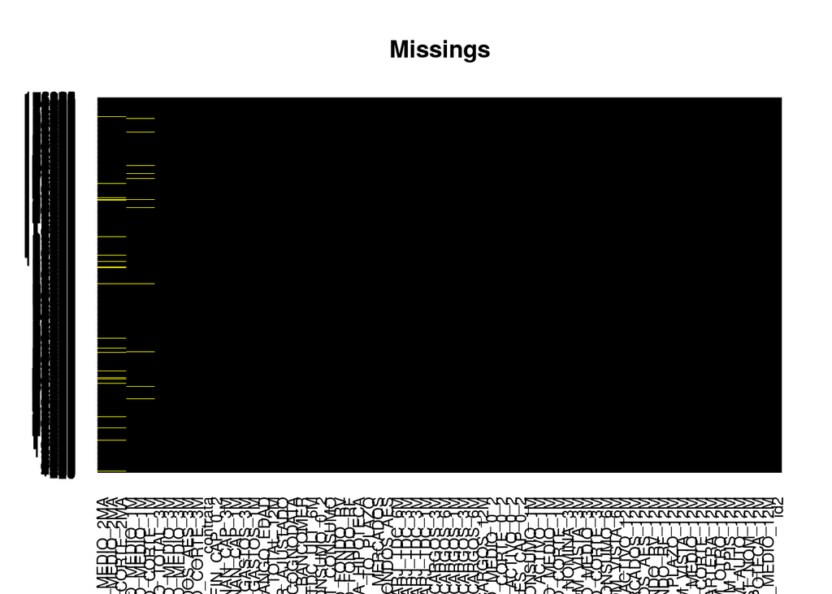

```r
ncero<-data.frame(colSums(is.na(cmult)))
cmult<-cmult[rownames(subset(ncero,subset=colSums.is.na.cmult..<100000))]

missmap(cmult, main="Missings",
        col=c("yellow", "black"), legend=FALSE)
```

[figure not shown]

```r
datana<-is.na(cmult)
cmult[datana]<-0

missmap(cmult, main="Missings",
        col=c("yellow", "black"), legend=FALSE)
```

```r
library(corrplot)

a<-c(1)
newmult<-cmult[-a]

ncero<-data.frame(colSums(newmult))
newmult<-newmult[rownames(subset(ncero,subset=colSums.newmult.!=0))]
newmult$contrata<-as.factor(newmult$contrata)
#newmult<-data.frame(scale(newmult) )

#missmap(newmult, main="Missings",
#        col=c("yellow", "black"), legend=FALSE)
```

```r
#mat<-cor(newmult)

#corrplot(mat,tl.cex=0.1,method='square')
```

```r
#library(FactoMineR)
#res.pca = PCA(newmult, scale.unit=FALSE, ncp=5, graph=F)
#plot.PCA(res.pca, choix="var",invisible="ind")
```

```r
# PCA

# Importing the dataset
dataset =newmult

# Splitting the dataset into the Training set and Test set
# install.packages('caTools')
library(caTools)
set.seed(123)
split = sample.split(dataset$contrata, SplitRatio = 0.8)
training_set = subset(dataset, split == TRUE)
test_set = subset(dataset, split == FALSE)

# Feature Scaling
training_set[-68] = scale(training_set[-68])
test_set[-68] = scale(test_set[-68])

# Applying PCA
# install.packages('caret')
library(caret)
# install.packages('e1071')
library(e1071)
pca = preProcess(x = training_set[-68], method = 'pca', pcaComp = 18)
training_set = predict(pca, training_set)
#training_set = training_set[c(2, 3, 1)]
test_set = predict(pca, test_set)
#test_set = test_set[c(2, 3, 1)]

# Fitting SVM to the Training set
# install.packages('e1071')
library(e1071)
#classifier = svm(formula = contrata~ .,
#                 data = training_set,
#                 type = 'C-classification',
#                 kernel = 'linear')
```

[output not shown]